# Bike Store Sales Analytics

### SQL & Python Business Intelligence Project

Derek Eodice, MBA, MSc

## Introduction

Retail organizations rely heavily on transactional data to guide decisions around pricing, inventory management, customer targeting, and store performance optimization.  
This project analyzes a relational sales database for a multi-store bike retailer to uncover revenue drivers, customer behavior patterns, and time-based performance trends.

The dataset is sourced from a normalized relational schema commonly used for SQL training and business analytics, consisting of customers, orders, products, brands, categories, and stores.  
The analysis is performed using **MySQL for querying** and **Python for orchestration, analysis, and visualization**.

## Objectives

The primary objectives of this project are to:

- Evaluate revenue performance across stores, products, and time
- Understand customer distribution and lifetime value
- Identify seasonality and growth trends
- Demonstrate the use of SQL for analytical reporting and metric development
- Integrate SQL outputs with Python for exploratory analysis and visualization

This project is designed to mirror real-world analytics workflows used in product, operations, and growth analytics teams.

## Dataset Overview

The database follows a normalized transactional schema and includes the following core tables:

- **customers**: customer demographics and location
- **orders**: order-level transaction data
- **order_items**: line-item level sales data
- **products**: product catalog
- **brands** and **categories**: product metadata
- **stores**: store-level attributes

This structure enables analysis at multiple levels of granularity, including:

- Customer-level behavior
- Product and brand performance
- Store-level revenue contribution
- Time-series revenue trends

The relational design closely resembles production OLTP systems commonly queried by analytics teams.

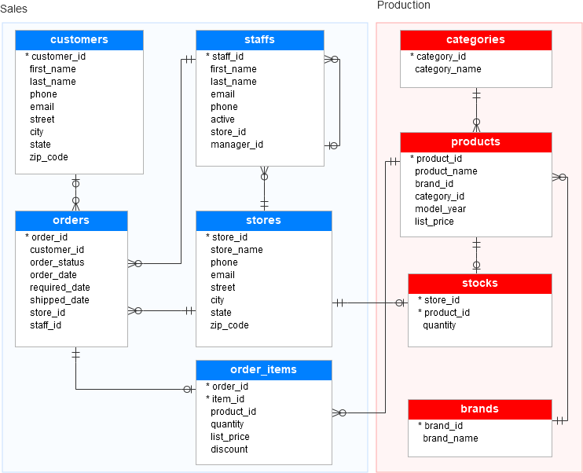

## Technical Approach

This project uses a hybrid SQL–Python workflow:

- **SQL (MySQL)** is used to:
  - Join relational tables
  - Aggregate metrics such as revenue, order volume, and customer value
  - Apply window functions and common table expressions (CTEs)
  - Perform time-based analyses
- **Python** is used to:
  - Execute SQL queries programmatically
  - Load results into pandas DataFrames
  - Perform exploratory data analysis (EDA)
  - Generate visualizations and narrative insights

This separation mirrors production analytics environments where SQL handles data retrieval and Python supports analysis and presentation.

# Part 1: Data Upload and Data Queries

## Connect to MYSQL and load the data

```
Successfully connected to the database.
  Tables_in_bike_store
0               brands
1           categories
2            customers
3          order_items
4               orders
5             products
6               staffs
7               stocks
8               stores
Connection closed.
```

## Create the tables and queries

```
Successfully connected to the database.

--- Customer Query Results ---
  customer_id  first_name last_name           phone                    email  \
0           1       Debra     Burks            None    debra.burks@yahoo.com
1           2       Kasha      Todd            None     kasha.todd@yahoo.com
2           3      Tameka    Fisher            None    tameka.fisher@aol.com
3           4       Daryl    Spence            None     daryl.spence@aol.com
4           5  Charolette      Rice  (916) 381-6003  charolette.rice@msn.com

                  street           city state zip_code
0      9273 Thorne Ave.    Orchard Park    NY    14127
1       910 Vine Street        Campbell    CA    95008
2  769C Honey Creek St.   Redondo Beach    CA    90278
3        988 Pearl Lane       Uniondale    NY    11553
4         107 River Dr.      Sacramento    CA    95820

--- State Counts Query Results ---
  state  state_count
0    NY         4076
1    CA         1136
2    TX          568

--- Customer Counts Query Results ---
              name  name_count
0  Justina Jenkins           8
1      Debra Burks           4
2       Kasha Todd           4
3    Tameka Fisher           4
4     Daryl Spence           4

--- Order Counts Query Results ---
   order_date required_date shipped_date  order_count  required_count  \
0  2016-01-01    2016-01-03   2016-01-03            4               4
1  2016-01-01    2016-01-04   2016-01-03            4               4
2  2016-01-02    2016-01-05   2016-01-03            4               4
3  2016-01-03    2016-01-04   2016-01-05            4               4
4  2016-01-03    2016-01-06   2016-01-06            4               4

   shipped_count
```

[output cut: 75 more lines]

```
1442    Caroline Jenkins    10943.42
1443       Luciana Mcgee    10751.49
1444  Stephanie Browning     6687.39

[1445 rows x 2 columns]

---Month Over Month Revenues---
   year  month     revenue  prev_revenue  mom_growth_pct
0  2016      1  3442342.79           NaN             NaN
1  2016      2  2497797.16    3442342.79          -27.44
2  2016      3  2889605.26    2497797.16           15.69
3  2016      4  2674304.82    2889605.26           -7.45
4  2016      5  3284320.15    2674304.82           22.81

Connection closed.
```

# Part 2: Exploratory Data Analysis

## Customer & Geographic Analysis

The analysis begins with an exploration of the customer base to understand:

- Geographic distribution of customers
- Concentration of orders by state
- Variability in customer ordering behavior

Understanding where customers are located and how frequently they purchase provides early insight into market concentration and potential regional growth opportunities.

```
geo
Mount Vernon, NY 10550    80
Ballston Spa, NY 12020    68
Scarsdale, NY 10583       68
Canandaigua, NY 14424     56
Ossining, NY 10562        52
Name: count, dtype: int64
```

```
                       geo   latitude   longitude
0   Orchard Park, NY 14127  42.767038  -78.743552
1       Campbell, CA 95008  37.287063 -121.944881
2  Redondo Beach, CA 90278  33.839829 -118.384594
3      Uniondale, NY 11553  40.709583  -73.592341
4     Sacramento, CA 95820  38.581061 -121.493895
```

[interactive chart not shown]

## Customer and State Representation Analysis

**Preliminary Customer Analysis**

There were 3 states and a total of 5780 orders represented in our relational database. The majority of the customers in the dataset were from NY with 4076 orders.

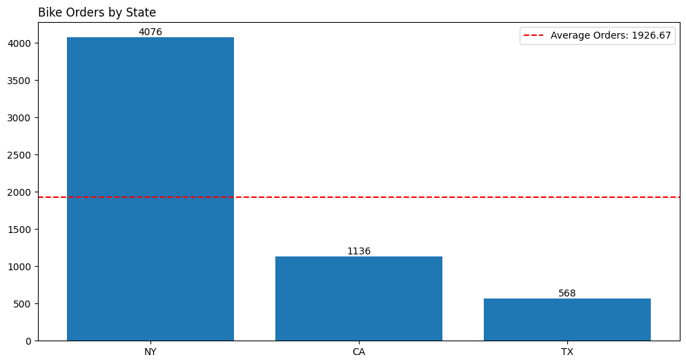

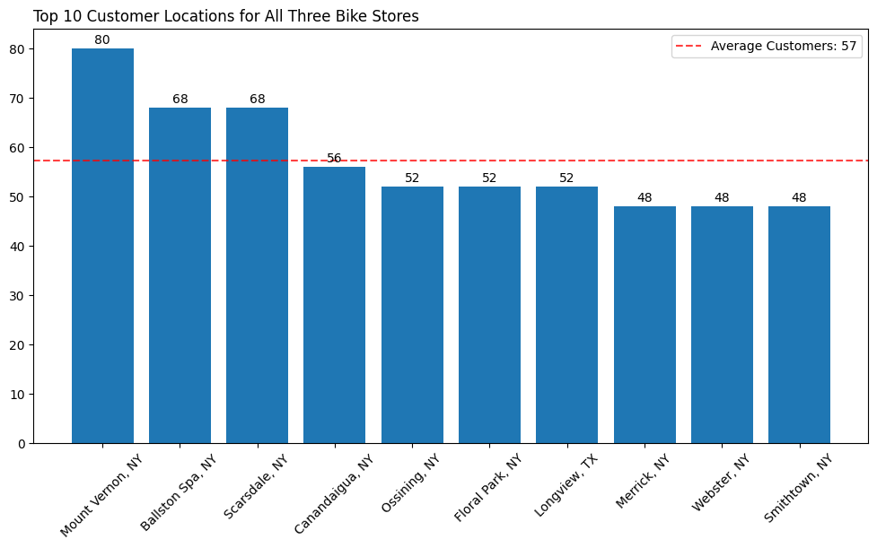

# Part 3: Order and Revenue Analysis

## Order Volume & Demand Analysis

In addition to revenue, understanding **order volume trends** is critical for interpreting overall business performance.  
Revenue growth can be driven by higher prices, larger baskets, or increased customer demand — order volume helps isolate the demand component.

To evaluate demand patterns, order data is aggregated at a monthly level across all stores. Order dates are first converted to true datetime values, enabling reliable time-based grouping and trend analysis.

### Monthly Order Trends

Total monthly orders are calculated by grouping orders by year and month and summing order counts across all stores.

This analysis enables:

- Identification of seasonality in customer purchasing behavior
- Comparison of monthly demand against long-term averages
- Detection of sustained growth or contraction in order activity

A horizontal reference line is included to represent the **average monthly order volume**, providing context for above- and below-average periods.

|  | order_date | required_date | shipped_date | order_count | required_count | shipped_count | month |
| --- | --- | --- | --- | --- | --- | --- | --- |
| 0 | 2016-01-01 | 2016-01-03 | 2016-01-03 | 4 | 4 | 4 | 2016-01 |
| 1 | 2016-01-01 | 2016-01-04 | 2016-01-03 | 4 | 4 | 4 | 2016-01 |
| 2 | 2016-01-02 | 2016-01-05 | 2016-01-03 | 4 | 4 | 4 | 2016-01 |
| 3 | 2016-01-03 | 2016-01-04 | 2016-01-05 | 4 | 4 | 4 | 2016-01 |
| 4 | 2016-01-03 | 2016-01-06 | 2016-01-06 | 4 | 4 | 4 | 2016-01 |
| ... | ... | ... | ... | ... | ... | ... | ... |
| 1395 | 2018-09-06 | 2018-09-06 | None | 4 | 4 | 0 | 2018-09 |
| 1396 | 2018-10-21 | 2018-10-21 | None | 4 | 4 | 0 | 2018-10 |
| 1397 | 2018-11-18 | 2018-11-18 | None | 4 | 4 | 0 | 2018-11 |
| 1398 | 2018-11-28 | 2018-11-28 | None | 4 | 4 | 0 | 2018-11 |
| 1399 | 2018-12-28 | 2018-12-28 | None | 4 | 4 | 0 | 2018-12 |

1400 rows × 7 columns

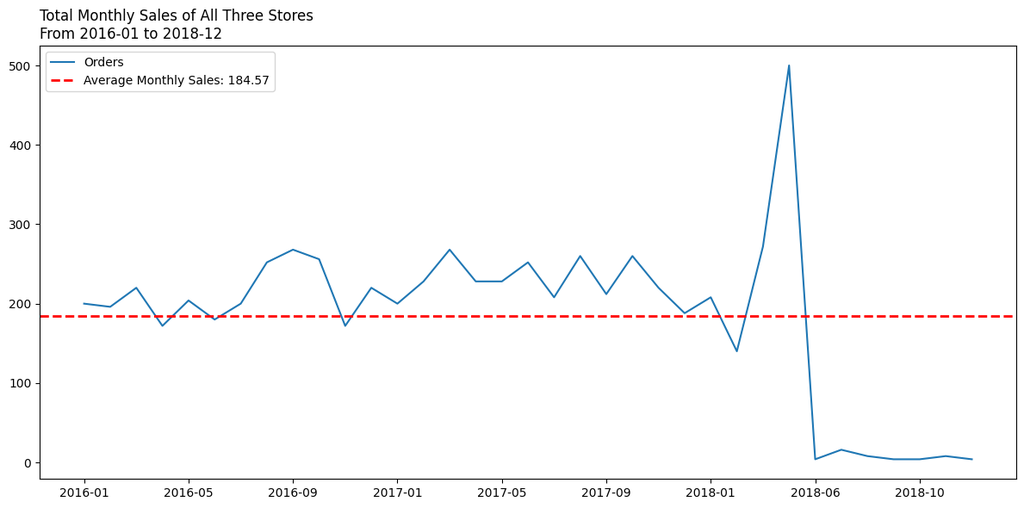

## Key Observations from Order Trends

When combined with revenue metrics, order trends help distinguish whether revenue changes are driven by:

- Increased customer demand (higher order volume)
- Higher average order value (AOV)
- Changes in product mix or pricing

This distinction is critical for operational planning, marketing strategy, and inventory management.

## Linking Order Volume to Revenue Performance

Analyzing order volume alongside revenue provides a more complete picture of business performance.

- Rising revenue paired with flat order volume suggests higher AOV or pricing effects
- Rising order volume with stable revenue may indicate discounting or lower-priced product mix
- Simultaneous growth in both metrics indicates strong overall business momentum

This integrated view mirrors how analytics teams evaluate growth drivers in retail and e-commerce environments.

## Average Order Value (AOV)

Average Order Value (AOV) is calculated at the store and year level to understand purchasing behavior and pricing dynamics.

AOV provides insight into:

- Differences in customer purchasing patterns across stores
- Potential impacts of pricing, promotions, or product mix
- Store-level performance beyond raw revenue totals

This metric is frequently used by product and growth teams to evaluate monetization strategies.

```
year              2016  2017  2018
store_name
Baldwin Bikes      438   482   173
Rowlett Bikes       65    75    34
Santa Cruz Bikes   132   131    85
```

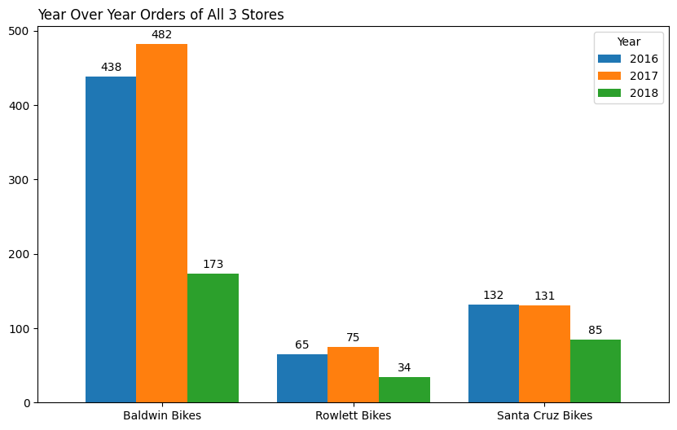

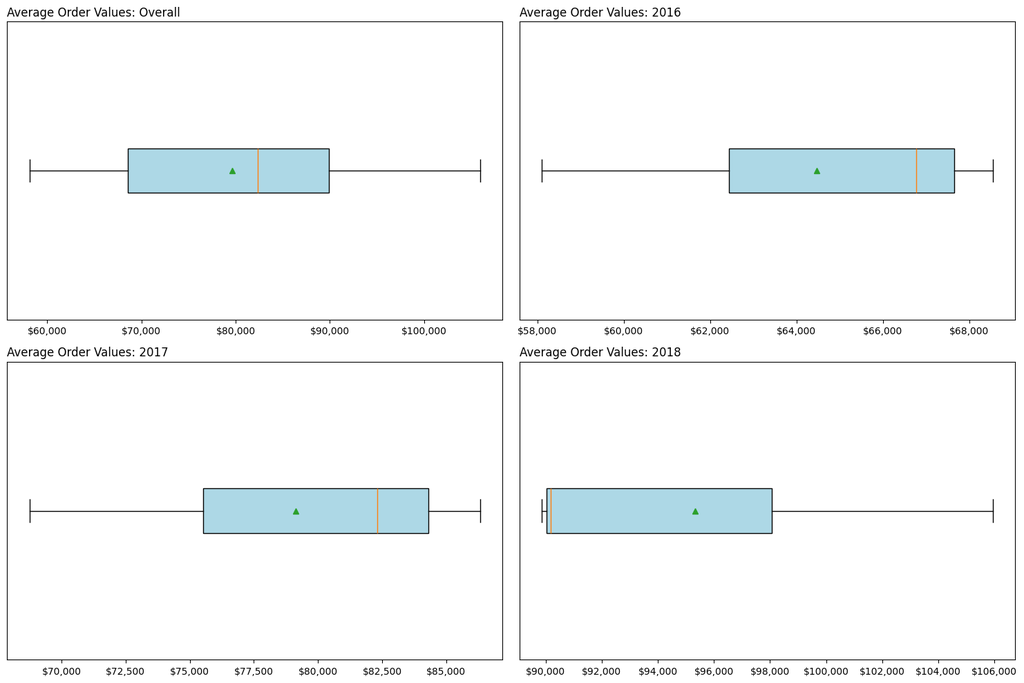

" **Order Values**

The average order value for all years was $79,644.61. The breakdown of annual average order values across all three stores for each year is as follows:

- **2016**: $64,475.62

- **2017**: $79,127.53

  - Difference from previous year: $14,651.91

- **2018**: $95,330.69

  - Difference from previous year: $16,203.15

## Customer Lifetime Value Analysis

Customer Lifetime Value (CLV) is calculated as the total revenue generated by each customer across all orders.

CLV analysis highlights:

- The degree to which revenue is concentrated among a subset of customers
- High-value customers who may warrant targeted retention strategies
- Long-tail customer behavior typical of retail environments

Understanding CLV is critical for customer segmentation, loyalty programs, and marketing ROI analysis.

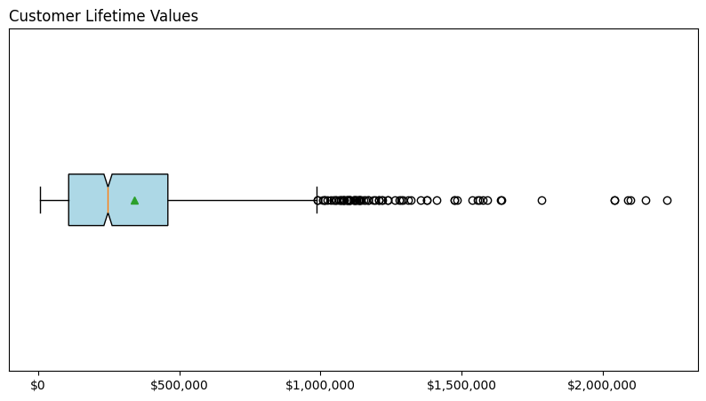

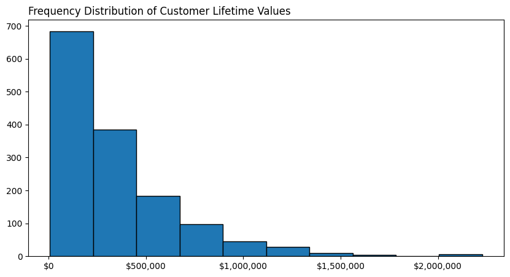

- For the 1,445 customers in our dataset, the average customer lifetime value was $340,556.03.

- It should be noted that our data is skewed to the right and impacts our average values in part to the number of outliers present in our dataset.

- These outliers are confirmed both by the boxplot (circles are outliers), and the tail of our histogram indicating a sizable number of high value outliers.

- Tying into the outliers, the customer with the highest lifetime value was Sharyn Hopkins, with a lifetime value of $2,227,708.11.

- Meanwhile, the customer with the lowest lifetime value was Stephanie Browning with a lifetime value of $6,687.39.

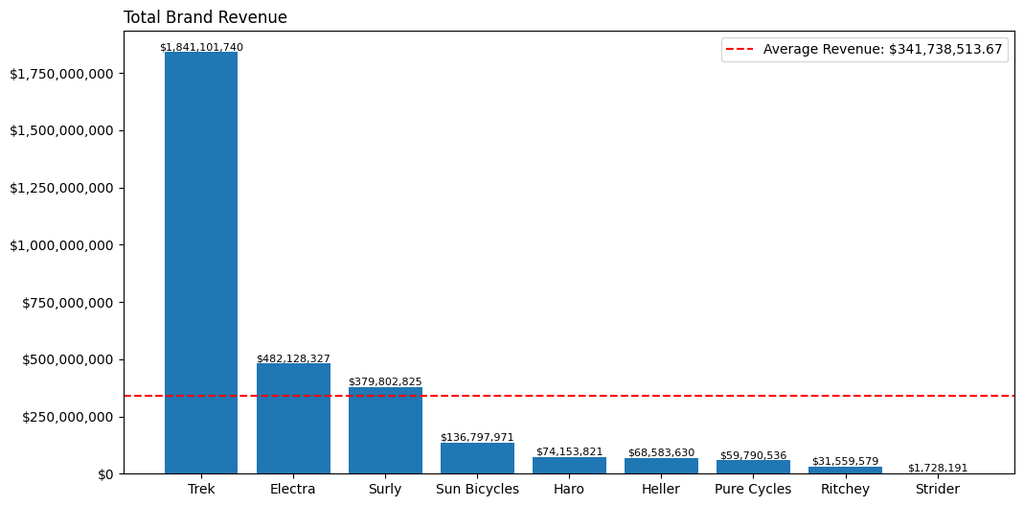

**Brand Revenue Analysis**

- The lowest selling brand overall was Strider with a total revenue of $1,728,191.56.

# Revenue over time

## Time-Series Analysis & Growth Trends

To evaluate revenue momentum over time, a Common Table Expression (CTE) and window function are used to calculate **month-over-month (MoM) revenue growth**.

This approach enables:

- Identification of seasonal patterns
- Detection of periods of acceleration or slowdown
- Comparison of current performance against historical benchmarks

Window functions are commonly used in analytics engineering and business intelligence workflows to support trend analysis without complex subqueries.

|  | year | month | revenue | prev_revenue | mom_growth_pct |
| --- | --- | --- | --- | --- | --- |
| 0 | 2016 | 1 | 3442342.79 | NaN | NaN |
| 1 | 2016 | 2 | 2497797.16 | 3442342.79 | -27.44 |
| 2 | 2016 | 3 | 2889605.26 | 2497797.16 | 15.69 |
| 3 | 2016 | 4 | 2674304.82 | 2889605.26 | -7.45 |
| 4 | 2016 | 5 | 3284320.15 | 2674304.82 | 22.81 |
| 5 | 2016 | 6 | 3368993.99 | 3284320.15 | 2.58 |
| 6 | 2016 | 7 | 3192908.94 | 3368993.99 | -5.23 |
| 7 | 2016 | 8 | 3610518.03 | 3192908.94 | 13.08 |
| 8 | 2016 | 9 | 4369465.76 | 3610518.03 | 21.02 |
| 9 | 2016 | 10 | 3393249.29 | 4369465.76 | -22.34 |
| 10 | 2016 | 11 | 2917270.60 | 3393249.29 | -14.03 |
| 11 | 2016 | 12 | 3197279.67 | 2917270.60 | 9.60 |
| 12 | 2017 | 1 | 4569863.74 | 3197279.67 | 42.93 |
| 13 | 2017 | 2 | 5006779.95 | 4569863.74 | 9.56 |
| 14 | 2017 | 3 | 4942590.43 | 5006779.95 | -1.28 |
| 15 | 2017 | 4 | 3636654.61 | 4942590.43 | -26.42 |
| 16 | 2017 | 5 | 4291731.81 | 3636654.61 | 18.01 |
| 17 | 2017 | 6 | 6061850.46 | 4291731.81 | 41.24 |
| 18 | 2017 | 7 | 3679926.37 | 6061850.46 | -39.29 |
| 19 | 2017 | 8 | 4648855.29 | 3679926.37 | 26.33 |
| 20 | 2017 | 9 | 4694484.10 | 4648855.29 | 0.98 |
| 21 | 2017 | 10 | 4965252.94 | 4694484.10 | 5.77 |
| 22 | 2017 | 11 | 4505246.43 | 4965252.94 | -9.26 |
| 23 | 2017 | 12 | 4152095.76 | 4505246.43 | -7.84 |
| 24 | 2018 | 1 | 6102881.59 | 4152095.76 | 46.98 |
| 25 | 2018 | 2 | 3210528.98 | 6102881.59 | -47.39 |
| 26 | 2018 | 3 | 5823855.90 | 3210528.98 | 81.40 |
| 27 | 2018 | 4 | 13086749.77 | 5823855.90 | 124.71 |
| 28 | 2018 | 6 | 3023.86 | 13086749.77 | -99.98 |
| 29 | 2018 | 7 | 181406.40 | 3023.86 | 5899.17 |
| 30 | 2018 | 8 | 134045.04 | 181406.40 | -26.11 |
| 31 | 2018 | 9 | 143423.44 | 134045.04 | 7.00 |
| 32 | 2018 | 10 | 60498.05 | 143423.44 | -57.82 |
| 33 | 2018 | 11 | 181792.11 | 60498.05 | 200.49 |
| 34 | 2018 | 12 | 104271.47 | 181792.11 | -42.64 |

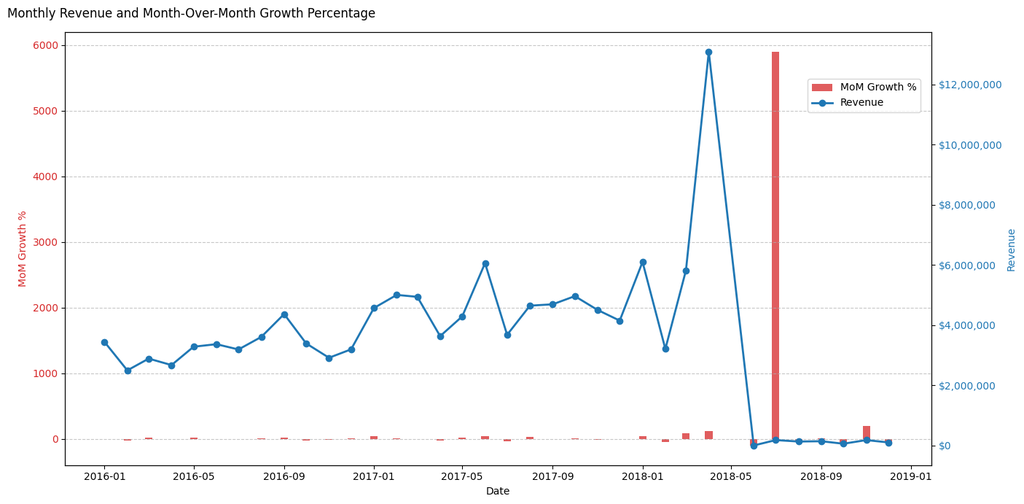

# Part 4: Key Takeaways, Future Work and Conclusion

## Key Business Insights

Key findings from the analysis include:

- Revenue is unevenly distributed across stores, with certain locations contributing disproportionately to total sales
- Customer lifetime value shows a long-tail distribution, where a small subset of customers generates a large share of revenue
- Product and brand performance varies significantly, highlighting opportunities for assortment optimization
- Time-series analysis suggests seasonal patterns and identifiable growth periods
- Average order value differs by store and year, indicating potential pricing or merchandising effects

These insights demonstrate how transactional data can be transformed into actionable business intelligence.

## Future Work: Revenue Forecasting

As a potential extension, this analysis could be expanded to include predictive modeling to forecast future revenue.

A simple forecasting approach could incorporate:

- Lagged revenue features
- Rolling averages
- Linear regression or tree-based models

Such models could support short-term planning, budgeting, and capacity forecasting while maintaining interpretability.

## Conclusion

This project demonstrates the use of SQL and Python to perform end-to-end business analytics on a relational dataset.  
By combining structured querying with exploratory analysis and clear business framing, the analysis reflects workflows commonly used in analytics and data science roles.

The focus on metrics, trends, and interpretability aligns with real-world decision-making contexts in retail and product-driven organizations.